# IE 360

Group Project

Refika Kalyoncu, Can Gizer, Ceren Dündar

2022-06-07

# 1 INTRODUCTION

The companies competing in energy distribution market are highly competitive. All the companies are selling the same undifferentiated product and the price that they charge their customers is fixed. This market behaves similar to a perfectly competitive market. The only exception being that the companies competing aren’t buying the electricity on the same price. The price is determined by energy consumption and prediction. During the timeslots where production is high and consumption is low, the prices tend to fall. By building time series models and trying to predict consumer behavior and energy production the distributor companies are trying to maximize their profits. Thus, the distributor companies are incentivized to make adequate time series models and forecasts. The aim of this project is showing parallels to what the energy distributors are doing. The aim is to predict energy production of a solar energy producer. The scope is, however, much smaller than what those distributors are doing, but in terms of building blocks, nothing drastic is different from how those energy distributors are modeling.  
The approach to tackle the problem, is explained in detail on the approach part and in the RMD file shared. But the model that the group decided on is an ARIMA model with 2 autoregressive variables and 1 moving average error model. This model is justifiable since, the energy production is highly correlated with the previous days. That is because the weather is not changing drastically on the area and thus the panels can operate similarly with the previous days.  
The production data is given hourly and as expected the production is 0 when the sun sets. Additionally, the production is at its daily maximum around noon when the sun exposure is at its highest. One additional thing to note is, the maximum daily production is increasing up to around 40 GW and then stays relatively constant. That’s the level the plant is working at its maximum capacity so to speak and operates at its optimum for some time. Then some decline can be observed in the data. That’s probably because the government has the authority to regulate individual plant’s production to stabilize energy prices on the energy distributor- producer market. Additionally, there are four possible regressors measured for 9 different longitude and latitude points. These are temperature, relative humidity, radiation and total cloud cover.

# 2 APPROACH

## 2.1 Libraries

The necessary libraries are added.

## 2.2 Uploading Data

The data is uploaded and updated each day for the corresponding prediction.

```r
data_path='C:/Users/Asus/Desktop/IE360/project/2022-05-23_production.csv'
production=fread(data_path)
production$date <- as.Date(production$date)
production[,trend:=1:.N]
data_path1='C:/Users/Asus/Desktop/IE360/project/2022-05-23_weather.csv'
inputs=fread(data_path1)
```

## 2.3 Dcasting and Merging with production

The data is dcasted to change so that each different lat and lon value for the same date and hour are avaliable in a single row.

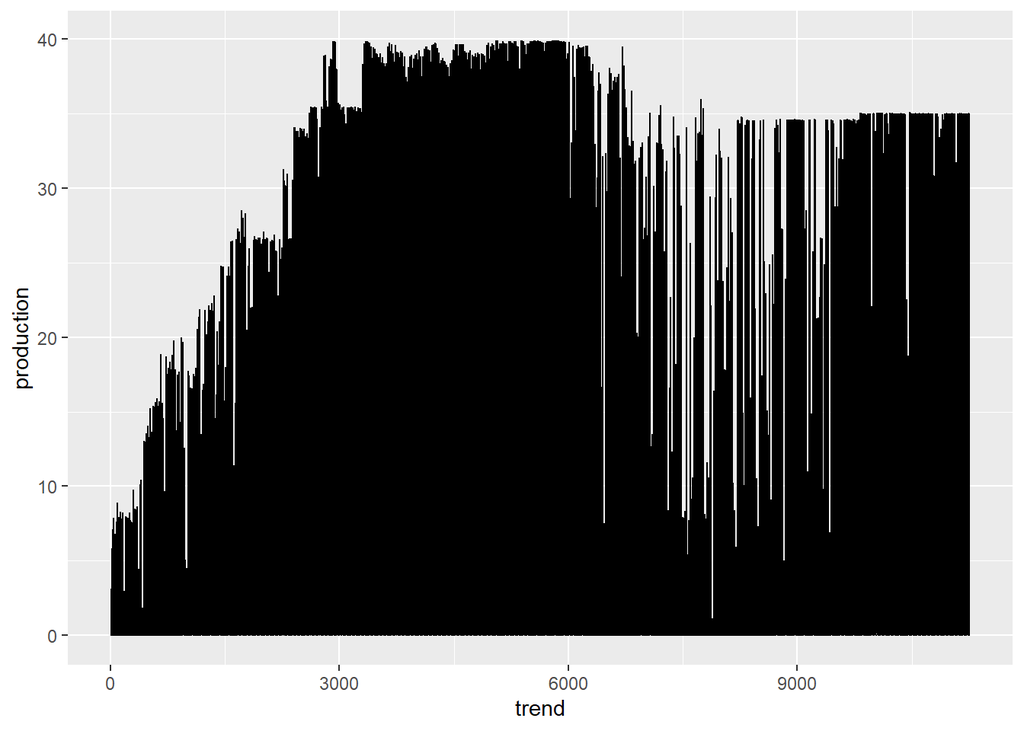

```r
ggplot(production, aes(y=production, x=trend))+geom_line()
```

```r
str(production)
```

```
## Classes 'data.table' and 'data.frame':   11256 obs. of  4 variables:
##  $ date      : Date, format: "2021-02-01" "2021-02-01" ...
##  $ hour      : int  0 1 2 3 4 5 6 7 8 9 ...
##  $ production: num  0 0 0 0 0 0 0 0 0.189 1.35 ...
##  $ trend     : int  1 2 3 4 5 6 7 8 9 10 ...
##  - attr(*, ".internal.selfref")=<externalptr>
```

```r
tmp=copy(production)
ff=dcast(inputs,date+hour~variable+lat+lon,value.var="value")
```

## 2.4 The database which includes the NA production values

```r
result=merge(ff, production,on="date",all = TRUE)
result$maxPro<-rep(NA,nrow(result))
result$dayHour<-paste(result$date, "-", result$hour)
```

```r
merged <- merge(ff, production,on="date")
merged$dayHour<-paste(merged$date, "-", merged$hour)
merged$maxPro<-rep(0,nrow(merged))
```

## 2.5 Finding The max function to find the max Production on last 30 days

```r
finding.max <- function(list) {
  maxi=0
  for(i in 1:31){
    if(list[i]$production>=maxi){
      maxi=list[i]$production
    }
  }
  ans=maxi
  maxi=0
  return(ans)
}
```

## 2.6 Creating 24 different data table for ease of implementation

```r
merged0=merged[merged$hour==0, ]
merged1=merged[merged$hour==1, ]
merged2=merged[merged$hour==2, ]
merged3=merged[merged$hour==3, ]
merged4=merged[merged$hour==4, ]
merged5=merged[merged$hour==5, ]
merged6=merged[merged$hour==6, ]
merged7=merged[merged$hour==7, ]
merged8=merged[merged$hour==8, ]
merged9=merged[merged$hour==9, ]
merged10=merged[merged$hour==10, ]
merged11=merged[merged$hour==11, ]
merged12=merged[merged$hour==12, ]
merged13=merged[merged$hour==13, ]
merged14=merged[merged$hour==14, ]
merged15=merged[merged$hour==15, ]
merged16=merged[merged$hour==16, ]
merged17=merged[merged$hour==17, ]
merged18=merged[merged$hour==18, ]
merged19=merged[merged$hour==19, ]
merged20=merged[merged$hour==20, ]
merged21=merged[merged$hour==21, ]
merged22=merged[merged$hour==22, ]
merged23=merged[merged$hour==23, ]
```

## 2.7 Copying the production value to Max Production column for first 30 Days

While we are looking for the max production we are searching for the max production in last 30 days but since the first 30 day doesn’t have the history we prefered to copy the production value directly as max.

```r
for(i in 1:720){
  merged[i]$maxPro=merged[i]$production
}
```

## 2.8 Finding the Max Production in last 30 days

Since all different hours have different patterns we prefered to assign the max production value in last 30 days and same hour.

```r
for(i in 31:(nrow(merged)/24)){
    lower=i-30
    upper=i
    merged[merged0[i]$trend]$maxPro=finding.max(merged0[lower:upper])
    merged[merged1[i]$trend]$maxPro=finding.max(merged1[lower:upper])
    merged[merged2[i]$trend]$maxPro=finding.max(merged2[lower:upper])
    merged[merged3[i]$trend]$maxPro=finding.max(merged3[lower:upper])
    merged[merged4[i]$trend]$maxPro=finding.max(merged4[lower:upper])
    merged[merged5[i]$trend]$maxPro=finding.max(merged5[lower:upper])
    merged[merged6[i]$trend]$maxPro=finding.max(merged6[lower:upper])
    merged[merged7[i]$trend]$maxPro=finding.max(merged7[lower:upper])
    merged[merged8[i]$trend]$maxPro=finding.max(merged8[lower:upper])
    merged[merged9[i]$trend]$maxPro=finding.max(merged9[lower:upper])
    merged[merged10[i]$trend]$maxPro=finding.max(merged10[lower:upper])
    merged[merged11[i]$trend]$maxPro=finding.max(merged11[lower:upper])
    merged[merged12[i]$trend]$maxPro=finding.max(merged12[lower:upper])
    merged[merged13[i]$trend]$maxPro=finding.max(merged13[lower:upper])
    merged[merged14[i]$trend]$maxPro=finding.max(merged14[lower:upper])
    merged[merged15[i]$trend]$maxPro=finding.max(merged15[lower:upper])
    merged[merged16[i]$trend]$maxPro=finding.max(merged16[lower:upper])
    merged[merged17[i]$trend]$maxPro=finding.max(merged17[lower:upper])
    merged[merged18[i]$trend]$maxPro=finding.max(merged18[lower:upper])
    merged[merged19[i]$trend]$maxPro=finding.max(merged19[lower:upper])
    merged[merged20[i]$trend]$maxPro=finding.max(merged20[lower:upper])
    merged[merged21[i]$trend]$maxPro=finding.max(merged21[lower:upper])
    merged[merged22[i]$trend]$maxPro=finding.max(merged22[lower:upper])


}
```

## 2.9 Utilization

The utilization of each hour is calculated by the diving the production level to max production in last 30 days in same hour.

```r
merged$utilization<-ifelse(merged$maxPro==0,0,merged$production/merged$maxPro*100)
```

## 2.10 Adding Utilization column to “data to be predicted” data to be able to rbind with the current data

As we merged production and weather csv files we prefered to erase the ones with NA value. However to be able to predict data we have to apply same column opperations to the “to be predicted” rows as well so we bind these data to the current table

```r
result$utilization<-rep(NA,nrow(result))
deneme2=rbind(merged,result[(nrow(result)-(7*24)+1):(nrow(result)-(4*24))])
```

## 2.11 Lag 72 Max Production

since we wont be able to calculate last 30 days’ max production for the last 72 data we prefered to copy the max Production of 3 days ago.

```r
for (i in (nrow(deneme2)-71):nrow(deneme2)){
  deneme2$maxPro[i]=deneme2$maxPro[i-72]
  deneme2$trend[i]=i
}
```

## 2.12 Basic Linear Regression Model

```r
merged <-deneme2
merged <- as.data.frame(merged)
modified <- subset(merged,select=-c(maxPro,dayHour,production))
lm1<-lm(utilization~.,modified)
summary(lm1)
```

```
##
## Call:
## lm(formula = utilization ~ ., data = modified)
##
## Residuals:
##     Min      1Q  Median      3Q     Max
## -116.80  -20.89   -6.91   13.91  108.21
##
## Coefficients:
##                               Estimate Std. Error t value Pr(>|t|)
## (Intercept)                  1.982e+04  8.260e+03   2.400 0.016411 *
## date                        -1.062e+00  4.425e-01  -2.401 0.016370 *
## hour                        -7.704e-01  4.934e-02 -15.616  < 2e-16 ***
## CLOUD_LOW_LAYER_36.25_33    -2.098e-02  2.580e-02  -0.813 0.416217
## CLOUD_LOW_LAYER_36.25_33.25 -6.714e-02  3.534e-02  -1.900 0.057509 .
## CLOUD_LOW_LAYER_36.25_33.5   7.606e-02  2.912e-02   2.612 0.009013 **
## CLOUD_LOW_LAYER_36.5_33     -7.266e-02  2.564e-02  -2.834 0.004610 **
## CLOUD_LOW_LAYER_36.5_33.25  -2.825e-02  3.316e-02  -0.852 0.394314
## CLOUD_LOW_LAYER_36.5_33.5   -6.196e-02  3.171e-02  -1.954 0.050725 .
## CLOUD_LOW_LAYER_36.75_33    -2.953e-02  2.183e-02  -1.353 0.176141
## CLOUD_LOW_LAYER_36.75_33.25 -8.755e-03  3.532e-02  -0.248 0.804226
## CLOUD_LOW_LAYER_36.75_33.5   1.317e-01  2.840e-02   4.638 3.57e-06 ***
## DSWRF_36.25_33              -3.622e-02  1.319e-02  -2.746 0.006040 **
## DSWRF_36.25_33.25            1.492e-03  1.766e-02   0.084 0.932707
## DSWRF_36.25_33.5             2.300e-02  1.397e-02   1.647 0.099581 .
## DSWRF_36.5_33                1.880e-02  1.265e-02   1.486 0.137280
## DSWRF_36.5_33.25            -1.770e-02  1.598e-02  -1.108 0.267905
## DSWRF_36.5_33.5              4.764e-02  1.499e-02   3.178 0.001489 **
## DSWRF_36.75_33               2.995e-02  1.085e-02   2.761 0.005769 **
## DSWRF_36.75_33.25           -1.114e-02  1.649e-02  -0.676 0.499342
## DSWRF_36.75_33.5             4.326e-02  1.305e-02   3.315 0.000920 ***
## REL_HUMIDITY_36.25_33       -1.311e-01  7.857e-02  -1.668 0.095281 .
## REL_HUMIDITY_36.25_33.25    -1.024e-01  1.187e-01  -0.863 0.388333
## REL_HUMIDITY_36.25_33.5      4.677e-01  8.161e-02   5.731 1.02e-08 ***
## REL_HUMIDITY_36.5_33        -2.864e-01  7.547e-02  -3.794 0.000149 ***
## REL_HUMIDITY_36.5_33.25     -3.382e-01  1.140e-01  -2.966 0.003021 **
## REL_HUMIDITY_36.5_33.5      -4.185e-01  9.352e-02  -4.475 7.71e-06 ***
## REL_HUMIDITY_36.75_33        4.594e-01  6.960e-02   6.601 4.28e-11 ***
## REL_HUMIDITY_36.75_33.25    -3.493e-01  9.765e-02  -3.577 0.000348 ***
## REL_HUMIDITY_36.75_33.5      4.795e-01  6.510e-02   7.366 1.89e-13 ***
## TEMP_36.25_33                2.310e+00  6.050e-01   3.819 0.000135 ***
## TEMP_36.25_33.25             3.614e+00  8.649e-01   4.179 2.95e-05 ***
## TEMP_36.25_33.5             -8.459e-01  5.642e-01  -1.499 0.133814
## TEMP_36.5_33                 1.319e+00  4.682e-01   2.817 0.004849 **
## TEMP_36.5_33.25             -4.747e+00  7.872e-01  -6.030 1.69e-09 ***
## TEMP_36.5_33.5               1.185e+00  5.057e-01   2.343 0.019167 *
## TEMP_36.75_33                3.988e+00  5.159e-01   7.730 1.17e-14 ***
## TEMP_36.75_33.25            -7.051e+00  6.734e-01 -10.470  < 2e-16 ***
## TEMP_36.75_33.5              3.920e-01  5.372e-01   0.730 0.465545
## trend                        4.461e-02  1.870e-02   2.386 0.017063 *
## ---
## Signif. codes:  0 '***' 0.001 '**' 0.01 '*' 0.05 '.' 0.1 ' ' 1
##
## Residual standard error: 29.68 on 11216 degrees of freedom
##   (72 observations deleted due to missingness)
## Multiple R-squared:  0.5304, Adjusted R-squared:  0.5287
## F-statistic: 324.8 on 39 and 11216 DF,  p-value: < 2.2e-16
```

## 2.13 Taking Averages

```r
avgmerged <- as.data.table(merged)

avgmerged$avgCLOUD <- (merged$CLOUD_LOW_LAYER_36.25_33+merged$CLOUD_LOW_LAYER_36.25_33.25+merged$CLOUD_LOW_LAYER_36.25_33.5+merged$CLOUD_LOW_LAYER_36.5_33+merged$CLOUD_LOW_LAYER_36.5_33.25+merged$CLOUD_LOW_LAYER_36.5_33.5+merged$CLOUD_LOW_LAYER_36.75_33+merged$CLOUD_LOW_LAYER_36.75_33.25+merged$CLOUD_LOW_LAYER_36.75_33.5)/9

avgmerged$avgTEMP<- (merged$TEMP_36.25_33+merged$TEMP_36.25_33.25+merged$TEMP_36.25_33.5+merged$TEMP_36.5_33+merged$TEMP_36.5_33.25+merged$TEMP_36.5_33.5+merged$TEMP_36.75_33+merged$TEMP_36.75_33.25+merged$TEMP_36.75_33.5)/9

avgmerged$avgHUM<- (merged$REL_HUMIDITY_36.25_33+merged$REL_HUMIDITY_36.25_33.25+merged$REL_HUMIDITY_36.25_33.5+merged$REL_HUMIDITY_36.5_33+merged$REL_HUMIDITY_36.5_33.25+merged$REL_HUMIDITY_36.5_33.5+merged$REL_HUMIDITY_36.75_33+merged$REL_HUMIDITY_36.75_33.25+merged$REL_HUMIDITY_36.75_33.5)/9

avgmerged$avgDSWRF<- (merged$DSWRF_36.25_33+merged$DSWRF_36.25_33.25+merged$DSWRF_36.25_33.5+merged$DSWRF_36.5_33+merged$DSWRF_36.5_33.25+merged$DSWRF_36.5_33.5+merged$DSWRF_36.75_33+merged$DSWRF_36.75_33.25+merged$DSWRF_36.75_33.5)/9
```

## 2.14 Adding weekday, month and trend as new columns

```r
avgmerged[,w_day:=as.character(wday(date,label=T))]
avgmerged[,mon:=as.character(month(date,label=T))]
avgmerged[,trend:=1:.N]
```

## 2.15 Adding Lag Utilizations

We added lag 72 for utilization because clearly it has a high autocorrelation in a period of 24 due to hours as you can see from the below graph and we are not able to reach the lag24 since we are predicting 72 rows ahead.

## 2.16 ACF

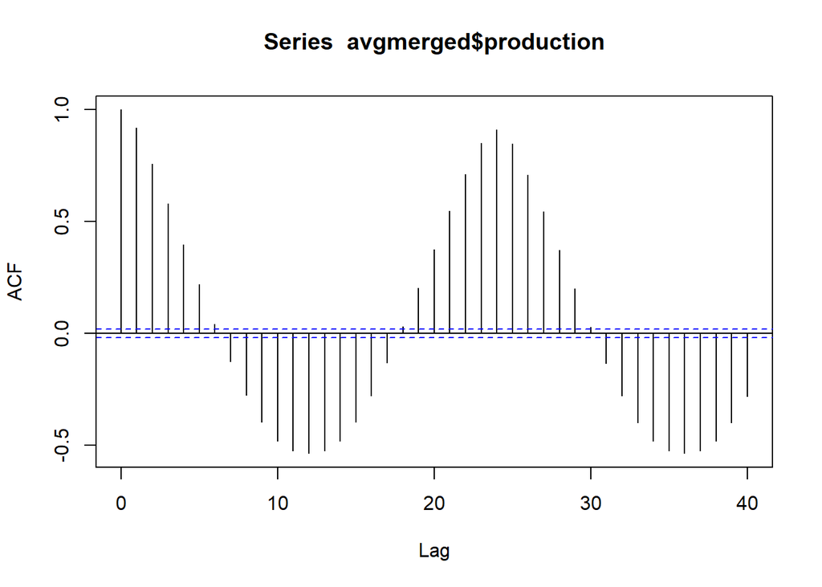

```r
acf(avgmerged$production,na.action = na.pass)
```

Also we prefered to add lag 73 since normally lag 1 is highly correlated and closes we can get is lag 73.  
We also added weekly (168), monthly (720) lag as well as 15 day since we observed that within 15 day periods production is tend to increase once in a while.

```r
avgmerged[,lag72_u:=shift(merged$utilization,24*3)]
avgmerged[,lag360_u:=shift(merged$utilization,24*15)]
avgmerged[,lag73_u:=shift(merged$utilization,24*3+1)]
avgmerged[,lag168_u:=shift(merged$utilization,168)]
avgmerged[,lag1_u:=shift(merged$utilization,1)]
avgmerged[,lag24_u:=shift(merged$utilization,24)]
avgmerged[,lag720_u:=shift(merged$utilization,720)]

avgmerged <- as.data.table(avgmerged)
```

# 3 Model 1

The model 1 is the basic model. It only includes the hour and date.

```r
lm1 <- lm(production~hour+date,avgmerged)
summary(lm1)
```

```
##
## Call:
## lm(formula = production ~ hour + date, data = avgmerged)
##
## Residuals:
##    Min     1Q Median     3Q    Max
## -12.81 -10.35  -8.89  12.04  30.02
##
## Coefficients:
##               Estimate Std. Error t value Pr(>|t|)
## (Intercept) -5.986e+01  1.850e+01  -3.235 0.001218 **
## hour         1.214e-01  1.943e-02   6.248 4.32e-10 ***
## date         3.652e-03  9.791e-04   3.731 0.000192 ***
## ---
## Signif. codes:  0 '***' 0.001 '**' 0.01 '*' 0.05 '.' 0.1 ' ' 1
##
## Residual standard error: 14.27 on 11253 degrees of freedom
##   (72 observations deleted due to missingness)
## Multiple R-squared:  0.004683,   Adjusted R-squared:  0.004506
## F-statistic: 26.47 on 2 and 11253 DF,  p-value: 3.382e-12
```

# 4 Model 2

Model 2 invvludes the average values hour and date.

```r
lm2 <- lm(production~avgHUM+avgTEMP+avgCLOUD+avgDSWRF+hour+date,avgmerged)
summary(lm2)
```

```
##
## Call:
## lm(formula = production ~ avgHUM + avgTEMP + avgCLOUD + avgDSWRF +
##     hour + date, data = avgmerged)
##
## Residuals:
##     Min      1Q  Median      3Q     Max
## -35.057  -6.253  -2.124   4.092  34.019
##
## Coefficients:
##               Estimate Std. Error t value Pr(>|t|)
## (Intercept) -2.643e+02  1.469e+01 -17.988  < 2e-16 ***
## avgHUM      -7.252e-02  8.282e-03  -8.756  < 2e-16 ***
## avgTEMP      1.161e-01  1.523e-02   7.623 2.68e-14 ***
## avgCLOUD     2.206e-03  4.796e-03   0.460    0.646
## avgDSWRF     3.367e-02  4.208e-04  80.028  < 2e-16 ***
## hour        -4.357e-01  1.429e-02 -30.488  < 2e-16 ***
## date         1.282e-02  6.925e-04  18.519  < 2e-16 ***
## ---
## Signif. codes:  0 '***' 0.001 '**' 0.01 '*' 0.05 '.' 0.1 ' ' 1
##
## Residual standard error: 9.698 on 11249 degrees of freedom
##   (72 observations deleted due to missingness)
## Multiple R-squared:  0.5405, Adjusted R-squared:  0.5403
## F-statistic:  2206 on 6 and 11249 DF,  p-value: < 2.2e-16
```

# 5 Model 3

In model 3 we tried to observe if deleting one of the average values improve the model or not.

```r
lm3 <- lm(production~avgHUM+avgTEMP+avgDSWRF+hour+date,avgmerged)
summary(lm3)
```

```
##
## Call:
## lm(formula = production ~ avgHUM + avgTEMP + avgDSWRF + hour +
##     date, data = avgmerged)
##
## Residuals:
##     Min      1Q  Median      3Q     Max
## -35.044  -6.259  -2.118   4.087  33.991
##
## Coefficients:
##               Estimate Std. Error t value Pr(>|t|)
## (Intercept) -2.653e+02  1.454e+01 -18.240  < 2e-16 ***
## avgHUM      -7.031e-02  6.751e-03 -10.415  < 2e-16 ***
## avgTEMP      1.166e-01  1.520e-02   7.669 1.87e-14 ***
## avgDSWRF     3.371e-02  4.123e-04  81.757  < 2e-16 ***
## hour        -4.352e-01  1.424e-02 -30.556  < 2e-16 ***
## date         1.286e-02  6.874e-04  18.714  < 2e-16 ***
## ---
## Signif. codes:  0 '***' 0.001 '**' 0.01 '*' 0.05 '.' 0.1 ' ' 1
##
## Residual standard error: 9.697 on 11250 degrees of freedom
##   (72 observations deleted due to missingness)
## Multiple R-squared:  0.5405, Adjusted R-squared:  0.5403
## F-statistic:  2647 on 5 and 11250 DF,  p-value: < 2.2e-16
```

# 6 Model 4

```r
lm4 <- lm(production~trend+TEMP_36.75_33.5+TEMP_36.75_33.25+TEMP_36.75_33+TEMP_36.5_33.25+TEMP_36.5_33+TEMP_36.25_33.25+TEMP_36.25_33+REL_HUMIDITY_36.75_33.5+REL_HUMIDITY_36.75_33.25+REL_HUMIDITY_36.75_33+REL_HUMIDITY_36.5_33.5+REL_HUMIDITY_36.25_33.5+REL_HUMIDITY_36.25_33+DSWRF_36.75_33.5+DSWRF_36.75_33.5+DSWRF_36.5_33.5+DSWRF_36.75_33+DSWRF_36.5_33.5+CLOUD_LOW_LAYER_36.75_33.5+CLOUD_LOW_LAYER_36.25_33+CLOUD_LOW_LAYER_36.25_33.5 +CLOUD_LOW_LAYER_36.25_33.25+CLOUD_LOW_LAYER_36.5_33 +hour+date,merged)
summary(lm4)
```

```
##
## Call:
## lm(formula = production ~ trend + TEMP_36.75_33.5 + TEMP_36.75_33.25 +
##     TEMP_36.75_33 + TEMP_36.5_33.25 + TEMP_36.5_33 + TEMP_36.25_33.25 +
##     TEMP_36.25_33 + REL_HUMIDITY_36.75_33.5 + REL_HUMIDITY_36.75_33.25 +
##     REL_HUMIDITY_36.75_33 + REL_HUMIDITY_36.5_33.5 + REL_HUMIDITY_36.25_33.5 +
##     REL_HUMIDITY_36.25_33 + DSWRF_36.75_33.5 + DSWRF_36.75_33.5 +
##     DSWRF_36.5_33.5 + DSWRF_36.75_33 + DSWRF_36.5_33.5 + CLOUD_LOW_LAYER_36.75_33.5 +
##     CLOUD_LOW_LAYER_36.25_33 + CLOUD_LOW_LAYER_36.25_33.5 + CLOUD_LOW_LAYER_36.25_33.25 +
##     CLOUD_LOW_LAYER_36.5_33 + hour + date, data = merged)
##
## Residuals:
##     Min      1Q  Median      3Q     Max
## -40.134  -5.967  -1.298   4.187  34.401
##
## Coefficients:
##                               Estimate Std. Error t value Pr(>|t|)
## (Intercept)                 -7.700e+03  2.476e+03  -3.110 0.001877 **
## trend                       -1.674e-02  5.605e-03  -2.986 0.002833 **
## TEMP_36.75_33.5              6.747e-01  1.586e-01   4.254 2.12e-05 ***
## TEMP_36.75_33.25            -2.671e+00  1.813e-01 -14.737  < 2e-16 ***
## TEMP_36.75_33                1.307e+00  1.385e-01   9.437  < 2e-16 ***
## TEMP_36.5_33.25             -1.406e+00  1.780e-01  -7.899 3.07e-15 ***
## TEMP_36.5_33                 3.178e-01  1.104e-01   2.879 0.004001 **
## TEMP_36.25_33.25             1.970e+00  1.481e-01  13.301  < 2e-16 ***
## TEMP_36.25_33                1.974e-01  1.533e-01   1.287 0.197970
## REL_HUMIDITY_36.75_33.5      1.046e-01  1.910e-02   5.476 4.43e-08 ***
## REL_HUMIDITY_36.75_33.25    -5.704e-02  2.542e-02  -2.243 0.024894 *
## REL_HUMIDITY_36.75_33        7.480e-02  1.651e-02   4.532 5.91e-06 ***
## REL_HUMIDITY_36.5_33.5      -1.767e-01  1.969e-02  -8.973  < 2e-16 ***
## REL_HUMIDITY_36.25_33.5      1.728e-01  1.429e-02  12.097  < 2e-16 ***
## REL_HUMIDITY_36.25_33       -1.256e-01  1.353e-02  -9.280  < 2e-16 ***
## DSWRF_36.75_33.5             9.088e-03  3.103e-03   2.928 0.003414 **
## DSWRF_36.5_33.5              1.611e-02  2.908e-03   5.540 3.09e-08 ***
## DSWRF_36.75_33               1.110e-02  1.962e-03   5.656 1.59e-08 ***
## CLOUD_LOW_LAYER_36.75_33.5   2.697e-02  5.747e-03   4.694 2.71e-06 ***
## CLOUD_LOW_LAYER_36.25_33     1.122e-02  6.941e-03   1.617 0.105911
## CLOUD_LOW_LAYER_36.25_33.5   2.779e-02  7.796e-03   3.564 0.000367 ***
## CLOUD_LOW_LAYER_36.25_33.25 -4.070e-02  9.664e-03  -4.211 2.56e-05 ***
## CLOUD_LOW_LAYER_36.5_33     -4.641e-02  5.180e-03  -8.960  < 2e-16 ***
## hour                        -2.816e-01  1.476e-02 -19.070  < 2e-16 ***
## date                         4.071e-01  1.326e-01   3.069 0.002150 **
## ---
## Signif. codes:  0 '***' 0.001 '**' 0.01 '*' 0.05 '.' 0.1 ' ' 1
##
## Residual standard error: 8.939 on 11231 degrees of freedom
##   (72 observations deleted due to missingness)
## Multiple R-squared:  0.6103, Adjusted R-squared:  0.6094
## F-statistic: 732.7 on 24 and 11231 DF,  p-value: < 2.2e-16
```

# 7 Model 5

With model 5 we added the lag values for lag 1 week, the latest data we can get and one before. Which ended up with 80 percent R value.

```r
lm5 <- lm(utilization~avgTEMP+avgHUM+avgDSWRF+lag168_u+avgCLOUD+hour+lag72_u+lag73_u,avgmerged)
summary(lm5)
```

```
##
## Call:
## lm(formula = utilization ~ avgTEMP + avgHUM + avgDSWRF + lag168_u +
##     avgCLOUD + hour + lag72_u + lag73_u, data = avgmerged)
##
## Residuals:
##     Min      1Q  Median      3Q     Max
## -95.086  -7.596  -2.160   6.887 101.433
##
## Coefficients:
##               Estimate Std. Error t value Pr(>|t|)
## (Intercept) 169.002850   8.879100  19.034  < 2e-16 ***
## avgTEMP      -0.545748   0.029510 -18.494  < 2e-16 ***
## avgHUM       -0.128490   0.016513  -7.781 7.84e-15 ***
## avgDSWRF      0.026896   0.001074  25.048  < 2e-16 ***
## lag168_u      0.380851   0.008068  47.203  < 2e-16 ***
## avgCLOUD     -0.173963   0.009613 -18.097  < 2e-16 ***
## hour         -0.170264   0.029269  -5.817 6.15e-09 ***
## lag72_u       0.454328   0.010521  43.184  < 2e-16 ***
## lag73_u      -0.036915   0.009717  -3.799 0.000146 ***
## ---
## Signif. codes:  0 '***' 0.001 '**' 0.01 '*' 0.05 '.' 0.1 ' ' 1
##
## Residual standard error: 19.14 on 11079 degrees of freedom
##   (240 observations deleted due to missingness)
## Multiple R-squared:  0.8034, Adjusted R-squared:  0.8032
## F-statistic:  5658 on 8 and 11079 DF,  p-value: < 2.2e-16
```

# 8 Model 6

We observe the effect of deleting the 1 week lag data.

```r
lm6 <- lm(utilization~avgTEMP+avgHUM+avgDSWRF+avgCLOUD+hour+lag72_u+lag73_u,avgmerged)
summary(lm6)
```

```
##
## Call:
## lm(formula = utilization ~ avgTEMP + avgHUM + avgDSWRF + avgCLOUD +
##     hour + lag72_u + lag73_u, data = avgmerged)
##
## Residuals:
##     Min      1Q  Median      3Q     Max
## -95.616  -9.358  -2.923   7.220  99.383
##
## Coefficients:
##               Estimate Std. Error t value Pr(>|t|)
## (Intercept) 155.982153   9.682531  16.110  < 2e-16 ***
## avgTEMP      -0.492317   0.032177 -15.300  < 2e-16 ***
## avgHUM       -0.122271   0.017957  -6.809 1.03e-11 ***
## avgDSWRF      0.037089   0.001146  32.364  < 2e-16 ***
## avgCLOUD     -0.166869   0.010445 -15.975  < 2e-16 ***
## hour         -0.269134   0.031747  -8.477  < 2e-16 ***
## lag72_u       0.737292   0.009428  78.203  < 2e-16 ***
## lag73_u      -0.041626   0.010536  -3.951 7.83e-05 ***
## ---
## Signif. codes:  0 '***' 0.001 '**' 0.01 '*' 0.05 '.' 0.1 ' ' 1
##
## Residual standard error: 20.91 on 11175 degrees of freedom
##   (145 observations deleted due to missingness)
## Multiple R-squared:  0.7659, Adjusted R-squared:  0.7658
## F-statistic:  5223 on 7 and 11175 DF,  p-value: < 2.2e-16
```

# 9 Interpretation of the models

## 9.1 We tried to observe what we get

```r
avgmerged[,predicted_reg:=predict(lm5,avgmerged)]
avgmerged$predicted_reg
```

[output not shown]

[output cut: 2251 more lines]

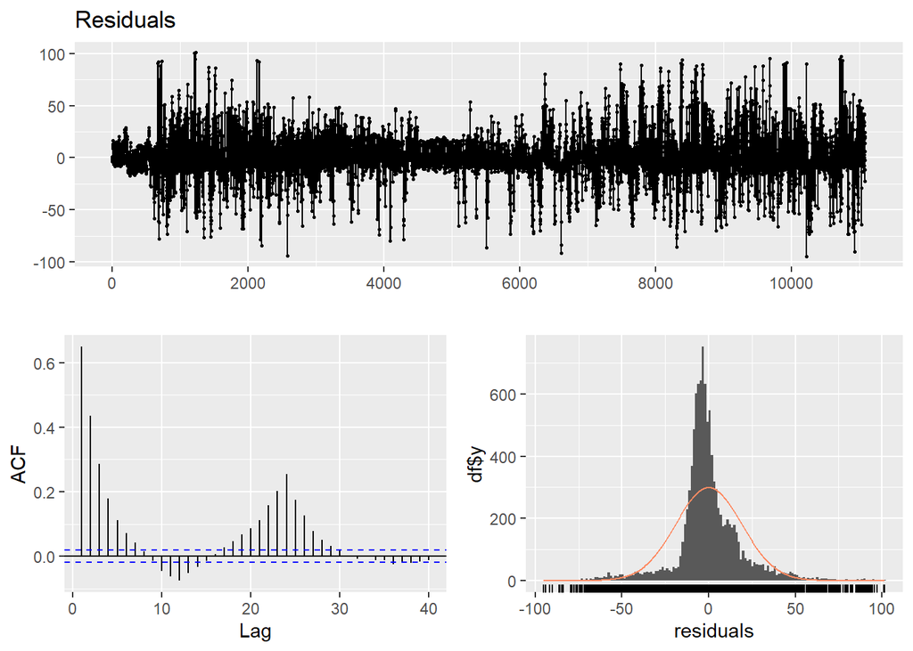

```
##
##  Breusch-Godfrey test for serial correlation of order up to 12
##
## data:  Residuals
## LM test = 4778.9, df = 12, p-value < 2.2e-16
```

```r
checkresiduals(lm5)
```

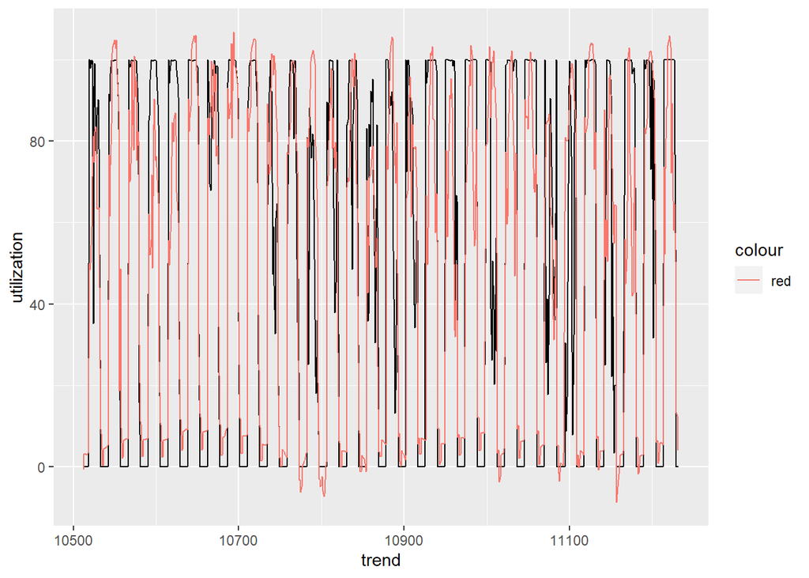

```r
ggplot(avgmerged[(11232-30*24):11232],aes(y=utilization,x=trend))+ geom_line()+
  geom_line(aes(y=predicted_reg, col="red"))
```

## 9.2 Negative and Invalid results

We eliminated the negative predictions and equalized them 0.

```r
for (i in 1:nrow(merged)){
  if (!is.na(avgmerged$predicted_reg[i]) && avgmerged$predicted_reg[i] <= 0){
    avgmerged$predicted_reg[i] = 0}
}
```

## 9.3 Non-productive hours

We observe that there is no production during 21:00-04:00 since there is no sun arround whole year in thpse times so we are directly equalizing them to 0.

```r
for (i in 1:nrow(merged)){
  if ((avgmerged$hour[i]==0) || (avgmerged$hour[i]==1) ||(avgmerged$hour[i]==2) ||(avgmerged$hour[i]==3) ||(avgmerged$hour[i]==4) ||(avgmerged$hour[i]==21) ||(avgmerged$hour[i]==22)||(avgmerged$hour[i]==23)){
    avgmerged$predicted[i] = 0}
}
```

## 9.4 Better Predictions

As we eliminated negative predictions and we equalized production to 0 during 21:00-04:00 predictions look better

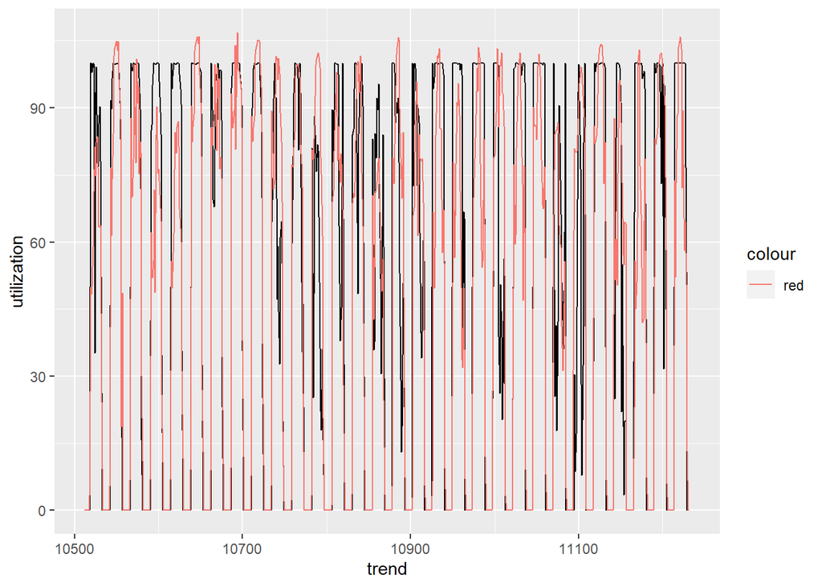

```r
ggplot(avgmerged[(11232-30*24):11232],aes(y=utilization,x=trend))+ geom_line()+
  geom_line(aes(y=predicted, col="red"))
```

# 10 Predicting

```r
LastDay=avgmerged[(nrow(avgmerged)-23):nrow(avgmerged),
                  c("avgTEMP","avgHUM","avgDSWRF","lag168_u","avgCLOUD","hour","lag72_u","lag73_u")]

LastDay=as.data.frame(LastDay)
prediction = c(0,0,0,0,0,0,0,0,0,0,0,0,0,0,0,0,0,0,0,0,0,0,0,0)
for(i in 1:24) {
  prediction[i] = predict(lm5,newdata=LastDay[i,])
  if(i==1 || i==2 ||i==3 || i==4 || i==5 || i==22 ||i==23 || i==24){
    prediction[i]=0
  }
}
prediction
```

```
##  [1]   0.0000000   0.0000000   0.0000000   0.0000000   0.0000000  75.0035984
##  [7]  55.2831040  71.4586615  85.5771214  87.2814911 101.5346889 102.8682374
## [13] 103.1133001  98.2937821  68.7688776  79.3336735  50.9757827  45.2480186
## [19]  52.2639493  27.4680445   0.2467981   0.0000000   0.0000000   0.0000000
```

```r
maxPros=avgmerged[(nrow(avgmerged)-23):nrow(avgmerged)]$maxPro

maxPros
```

```
##  [1]  0.00  0.00  0.00  0.00  0.00  0.12  7.37 27.66 35.00 35.00 35.00 35.00
## [13] 35.00 35.00 35.00 35.00 35.00 25.42  9.44  1.89  0.00  0.00  0.00  0.00
```

```r
theEnd=c(0,24)
for(i in 1:24) {
  theEnd[i]=prediction[i]*maxPros[i]/100
}
theEnd
```

```
##  [1]  0.00000000  0.00000000  0.00000000  0.00000000  0.00000000  0.09000432
##  [7]  4.07436477 19.76546576 29.95199249 30.54852187 35.53714110 36.00388307
## [13] 36.08965502 34.40282373 24.06910715 27.76678572 17.84152393 11.50204634
## [19]  4.93371682  0.51914604  0.00000000  0.00000000  0.00000000  0.00000000
```

The utilization data is differenced with 72 hour lagged values.  
This is done to achieve stationarity.  
72 is chosen sincedaily seasonality is apparent in data and the last data point we have to predict is 72 data point prior.

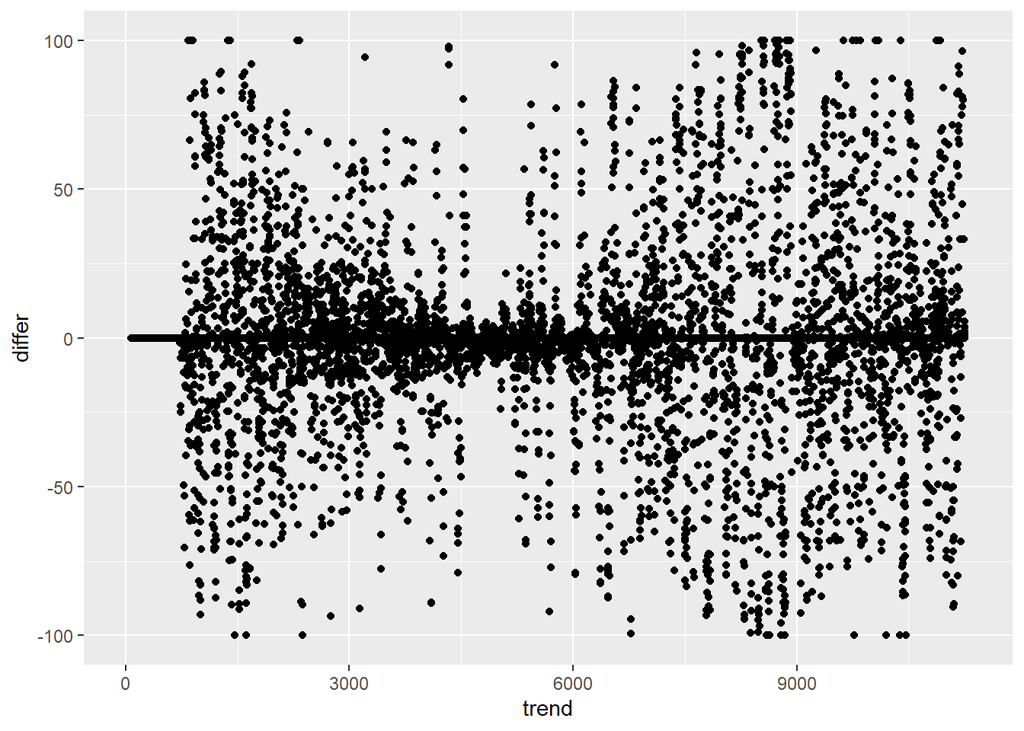

```r
avgmerged[,differ:=utilization-shift(utilization,72)]
ggplot(data=avgmerged, aes(x=trend, y=differ))+geom_point()
```

```r
head(avgmerged$trend,100)
```

```
##   [1]   1   2   3   4   5   6   7   8   9  10  11  12  13  14  15  16  17  18
##  [19]  19  20  21  22  23  24  25  26  27  28  29  30  31  32  33  34  35  36
##  [37]  37  38  39  40  41  42  43  44  45  46  47  48  49  50  51  52  53  54
##  [55]  55  56  57  58  59  60  61  62  63  64  65  66  67  68  69  70  71  72
##  [73]  73  74  75  76  77  78  79  80  81  82  83  84  85  86  87  88  89  90
##  [91]  91  92  93  94  95  96  97  98  99 100
```

The visual iinspection seems statitonary.

## 10.1 KPSS Test for Stationarity

```r
kpss= ur.kpss(avgmerged$differ)
summary(kpss)
```

```
##
## #######################
## # KPSS Unit Root Test #
## #######################
##
## Test is of type: mu with 13 lags.
##
## Value of test-statistic is: 0.05
##
## Critical value for a significance level of:
##                 10pct  5pct 2.5pct  1pct
## critical values 0.347 0.463  0.574 0.739
```

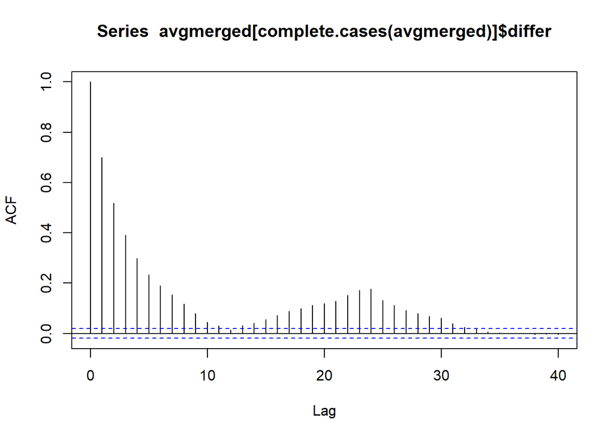

```r
acf(avgmerged[complete.cases(avgmerged)]$differ)
```

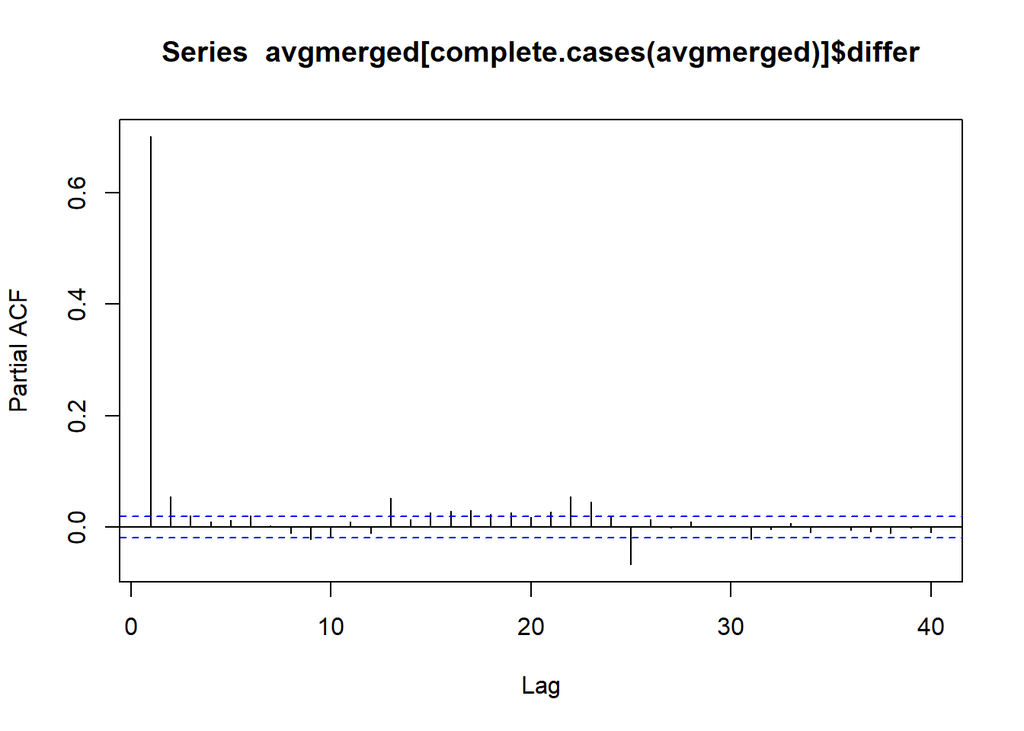

```r
pacf(avgmerged[complete.cases(avgmerged)]$differ)
```

# 11 Arima Model

```r
fitted=auto.arima(avgmerged$differ,seasonal=F,trace=T,stepwise=F,approximation=F)
```

```
##
##  ARIMA(0,0,0) with zero mean     : 102630.4
##  ARIMA(0,0,0) with non-zero mean : 102632.1
##  ARIMA(0,0,1) with zero mean     : 97767.2
##  ARIMA(0,0,1) with non-zero mean : 97769.05
##  ARIMA(0,0,2) with zero mean     : 96241.12
##  ARIMA(0,0,2) with non-zero mean : 96243.02
##  ARIMA(0,0,3) with zero mean     : 95634.19
##  ARIMA(0,0,3) with non-zero mean : 95636.11
##  ARIMA(0,0,4) with zero mean     : 95341.2
##  ARIMA(0,0,4) with non-zero mean : 95343.14
##  ARIMA(0,0,5) with zero mean     : 95234.97
##  ARIMA(0,0,5) with non-zero mean : 95236.91
##  ARIMA(1,0,0) with zero mean     : 95096.14
##  ARIMA(1,0,0) with non-zero mean : 95098.1
##  ARIMA(1,0,1) with zero mean     : 95063.55
##  ARIMA(1,0,1) with non-zero mean : 95065.51
##  ARIMA(1,0,2) with zero mean     : 95062.08
##  ARIMA(1,0,2) with non-zero mean : 95064.05
##  ARIMA(1,0,3) with zero mean     : 95062.9
##  ARIMA(1,0,3) with non-zero mean : 95064.87
##  ARIMA(1,0,4) with zero mean     : 95063.38
##  ARIMA(1,0,4) with non-zero mean : 95065.35
##  ARIMA(2,0,0) with zero mean     : 95065.37
##  ARIMA(2,0,0) with non-zero mean : 95067.34
##  ARIMA(2,0,1) with zero mean     : 95060.44
##  ARIMA(2,0,1) with non-zero mean : 95062.19
##  ARIMA(2,0,2) with zero mean     : Inf
##  ARIMA(2,0,2) with non-zero mean : Inf
##  ARIMA(2,0,3) with zero mean     : 95065.61
##  ARIMA(2,0,3) with non-zero mean : 95067.58
##  ARIMA(3,0,0) with zero mean     : 95062.96
##  ARIMA(3,0,0) with non-zero mean : 95064.93
##  ARIMA(3,0,1) with zero mean     : 95066.95
##  ARIMA(3,0,1) with non-zero mean : Inf
##  ARIMA(3,0,2) with zero mean     : Inf
##  ARIMA(3,0,2) with non-zero mean : Inf
##  ARIMA(4,0,0) with zero mean     : 95063.83
##  ARIMA(4,0,0) with non-zero mean : 95065.8
##  ARIMA(4,0,1) with zero mean     : 95066.33
##  ARIMA(4,0,1) with non-zero mean : 95068.3
##  ARIMA(5,0,0) with zero mean     : 95064.3
##  ARIMA(5,0,0) with non-zero mean : 95066.27
##
##
##
##  Best model: ARIMA(2,0,1) with zero mean
```

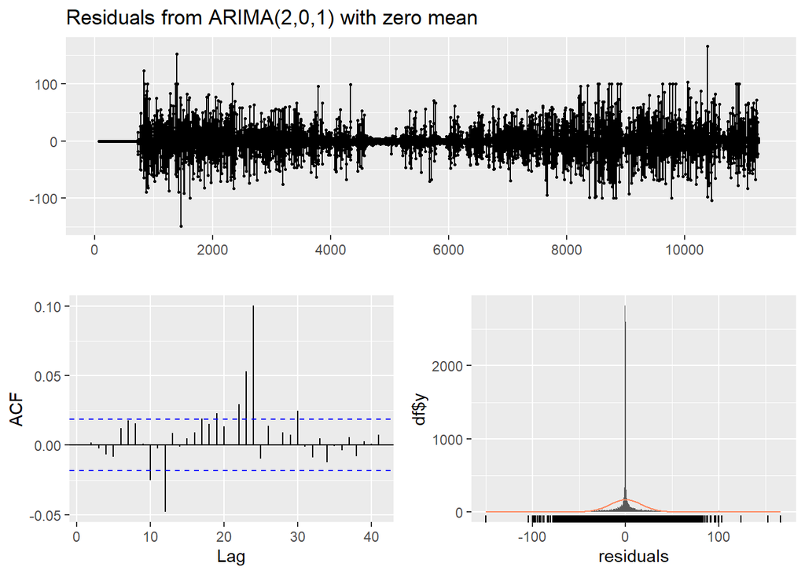

```
##
##  Ljung-Box test
##
## data:  Residuals from ARIMA(2,0,1) with zero mean
## Q* = 16.532, df = 7, p-value = 0.02068
##
## Model df: 3.   Total lags used: 10
```

```r
checkresiduals(fitted)
```

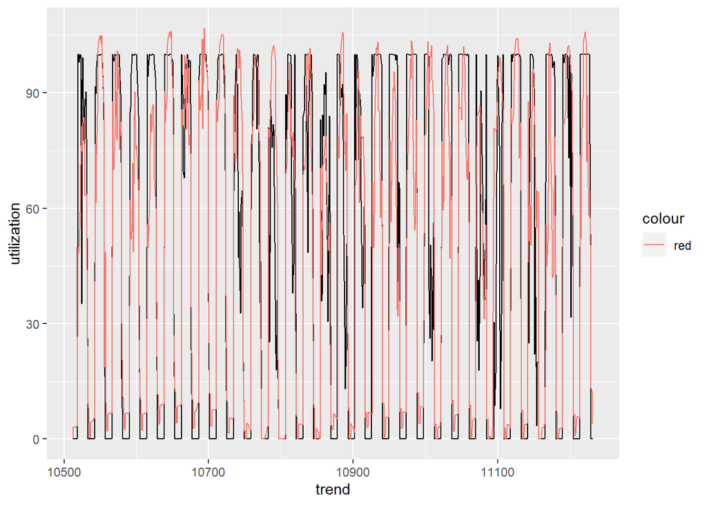

```r
ggplot(avgmerged[(11232-30*24):11232],aes(y=utilization,x=trend))+ geom_line()+
  geom_line(aes(y=predicted_reg, col="red"))
```

```r
forecasted=forecast(fitted,h=576)
forecasted
```

```
##       Point Forecast     Lo 80    Hi 80     Lo 95    Hi 95
## 11329   2.360513e-10 -30.48342 30.48342 -46.62037 46.62037
## 11330   1.819831e-10 -30.48342 30.48342 -46.62037 46.62037
## 11331   1.402994e-10 -30.48342 30.48342 -46.62037 46.62037
## 11332   1.081634e-10 -30.48342 30.48342 -46.62037 46.62037
## 11333   8.338832e-11 -30.48342 30.48342 -46.62037 46.62037
## 11334   6.428801e-11 -30.48342 30.48342 -46.62037 46.62037
## 11335   4.956267e-11 -30.48342 30.48342 -46.62037 46.62037
## 11336   3.821021e-11 -30.48342 30.48342 -46.62037 46.62037
## 11337   2.945806e-11 -30.48342 30.48342 -46.62037 46.62037
## 11338   2.271061e-11 -30.48342 30.48342 -46.62037 46.62037
## 11339   1.750869e-11 -30.48342 30.48342 -46.62037 46.62037
## 11340   1.349828e-11 -30.48342 30.48342 -46.62037 46.62037
## 11341   1.040646e-11 -30.48342 30.48342 -46.62037 46.62037
## 11342   8.022833e-12 -30.48342 30.48342 -46.62037 46.62037
```

[output cut: 562 more lines]

```r
temporary=copy(avgmerged)
test=avgmerged[9289:9864]
test$Date=avgmerged$Date+c(9289:9864)
test[,predicted_differ:=as.numeric(forecasted$mean)]
temporary=rbindlist(list(temporary,test),fill=T,use.names=T)
temporary[is.na(predicted_differ),predicted_differ:=differ]
```

```r
temporary[,forecastval:=predicted_differ+shift(utilization,72)]
head(temporary,24)
```

```
##           date hour CLOUD_LOW_LAYER_36.25_33 CLOUD_LOW_LAYER_36.25_33.25
##  1: 2021-02-01    0                       45                          31
##  2: 2021-02-01    1                       44                          26
##  3: 2021-02-01    2                       37                          35
##  4: 2021-02-01    3                       43                          45
##  5: 2021-02-01    4                       72                          95
##  6: 2021-02-01    5                       69                          95
##  7: 2021-02-01    6                       75                          96
##  8: 2021-02-01    7                       79                          97
##  9: 2021-02-01    8                       83                          97
## 10: 2021-02-01    9                       86                          97
## 11: 2021-02-01   10                      100                         100
## 12: 2021-02-01   11                      100                         100
## 13: 2021-02-01   12                       98                         100
## 14: 2021-02-01   13                       97                         100
```

[output cut: 375 more lines]

```r
temporary <- temporary[9289:9864]
```

With the help of shift function the difference predictions are converted to the utilization predictions.

## 11.1 MAD values

```r
mad_reg <- mad(temporary$utilization,temporary$predicted_reg)
mad_arima <- mad(temporary$utilization,temporary$predicted_differ)
```

# 12 RESULTS

[output not shown]

# 13 CONCLUSION AND FUTURE WORK

[output not shown]

# 14 References

[Kıvanç Enerji](https://www.kivancenerji.com.tr/kivanc2ges.html) [Enerji Atlası](https://www.enerjiatlasi.com/gunes/kivanc-2-ges.html)